# STAT 184: Final Project

Josiah Kim

07 December 2020

### Guiding Question

Do black students face disproportionate punishment compared to their white counterparts within the public school system?

### Become Acquainted with the Data

I found the data on The Civil Rights Project (https://www.civilrightsproject.ucla.edu/) who aim to renew the civil rights movement by creating a deeper understanding of the disparities. This data is collected and maintained by The Civil Rights Data Collection (https://ocrdata.ed.gov/). Every other year, all public schools are required to submit a repose to a survey to the U.S. Department of Education’s Office for Civil Rights. I will be using *Referrals and Arrests* and *Enrollment* data set which shows a record of students’ referrals and law enforcement intervention. Here is a peek of the data:

```r
# Load necessary packages
```

```
There were 12 warnings (use warnings() to see them)
```

```r
library(tidyverse)
library(gridExtra)
# Stage the data
refAndArrest <- read.csv("Referrals and Arrests.csv")
corPunishment <- read.csv("Corporal Punishment.csv")
expulsions <- read.csv("Expulsions.csv")
suspensions <- read.csv("Suspensions.csv")
enrollment <- read.csv("Enrollment.csv")
party <- read.csv("State_Party.csv")
```

#### Data Exploration of *Referrals and Arrests*

```r
nrow(refAndArrest)
```

```
[1] 97632
```

```r
ncol(refAndArrest)
```

```
[1] 84
```

```r
head(refAndArrest, 5)
```

|  | LEA_STATE | LEA_STATE_NAME | LEAID | LEA_NAME | SCHID | SCH_NAME | COMBOKEY | JJ | SCH_DISCWODIS_REF_HI_M | SCH_DISCWODIS_REF_HI_F | SCH_DISCWODIS_REF_AM_M | SCH_DISCWODIS_REF_AM_F | SCH_DISCWODIS_REF_AS_M | SCH_DISCWODIS_REF_AS_F | SCH_DISCWODIS_REF_HP_M | SCH_DISCWODIS_REF_HP_F | SCH_DISCWODIS_REF_BL_M | SCH_DISCWODIS_REF_BL_F | SCH_DISCWODIS_REF_WH_M | SCH_DISCWODIS_REF_WH_F | SCH_DISCWODIS_REF_TR_M | SCH_DISCWODIS_REF_TR_F | TOT_DISCWODIS_REF_M | TOT_DISCWODIS_REF_F | SCH_DISCWODIS_REF_LEP_M | SCH_DISCWODIS_REF_LEP_F | SCH_DISCWDIS_REF_IDEA_HI_M | SCH_DISCWDIS_REF_IDEA_HI_F | SCH_DISCWDIS_REF_IDEA_AM_M | … |
| --- | --- | --- | --- | --- | --- | --- | --- | --- | --- | --- | --- | --- | --- | --- | --- | --- | --- | --- | --- | --- | --- | --- | --- | --- | --- | --- | --- | --- | --- | --- |
| 1 | AL | ALABAMA | 0100002 | Alabama Youth Services | 1705 | Wallace Sch - Mt Meigs Campus | 010000201705 | Yes | -9 | -9 | -9 | -9 | -9 | -9 | -9 | -9 | -9 | -9 | -9 | -9 | -9 | -9 | -9 | -9 | -9 | -9 | -9 | -9 | -9 | … |
| 2 | AL | ALABAMA | 0100002 | Alabama Youth Services | 1706 | McNeel Sch - Vacca Campus | 010000201706 | Yes | -9 | -9 | -9 | -9 | -9 | -9 | -9 | -9 | -9 | -9 | -9 | -9 | -9 | -9 | -9 | -9 | -9 | -9 | -9 | -9 | -9 | … |
| 3 | AL | ALABAMA | 0100002 | Alabama Youth Services | 1876 | Alabama Youth Services | 010000201876 | No | 0 | 0 | 0 | 0 | 0 | 0 | 0 | 0 | 0 | 0 | 0 | 0 | 0 | 0 | 0 | 0 | 0 | 0 | 0 | 0 | 0 | … |
| 4 | AL | ALABAMA | 0100002 | Alabama Youth Services | 99995 | AUTAUGA CAMPUS | 010000299995 | Yes | -9 | -9 | -9 | -9 | -9 | -9 | -9 | -9 | -9 | -9 | -9 | -9 | -9 | -9 | -9 | -9 | -9 | -9 | -9 | -9 | -9 | … |
| 5 | AL | ALABAMA | 0100005 | Albertville City | 870 | Albertville Middle School | 010000500870 | No | 0 | 0 | 0 | 0 | 0 | 0 | 0 | 0 | 0 | 0 | 0 | 0 | 0 | 0 | 0 | 0 | 0 | 0 | 0 | 0 | 0 | … |

There are 97, 632 cases in this data set containing 84 variables. Each case represents a public school. I plan to use the following variables:

- *SCHID* - 5 Digit School Identification Code
- *SCH_NAME* - School Name
- *SCH_DISCWODIS_REF_BL_M* - Students without disabilities who were referred to a law enforcement agency or official: Black Male
- *SCH_DISCWODIS_REF_BL_F* - Students without disabilities who were referred to a law enforcement agency or official: Black Female
- *SCH_DISCWODIS_REF_WH_M* - Students without disabilities who were referred to a law enforcement agency or official: White Male
- *SCH_DISCWODIS_REF_WH_F* - Students without disabilities who were referred to a law enforcement agency or official: White Female
- *SCH_DISCWODIS_ARR_BL_M* - Students without disabilities who received a school-related arrest: Black Male
- *SCH_DISCWODIS_ARR_BL_F* - Students without disabilities who received a school-related arrest: Black Female
- *SCH_DISCWODIS_ARR_WH_M* - Students without disabilities who received a school-related arrest: White Male
- *SCH_DISCWODIS_ARR_WH_F* - Students without disabilities who received a school-related arrest: White Female

#### Data Exploration of *Enrollment*

```r
nrow(enrollment)
```

```
[1] 97632
```

```r
ncol(enrollment)
```

```
[1] 123
```

```r
head(enrollment, 5)
```

|  | LEA_STATE | LEA_STATE_NAME | LEAID | LEA_NAME | SCHID | SCH_NAME | COMBOKEY | JJ | SCH_PSENR_NONIDEA_A3 | SCH_PSENR_NONIDEA_A4 | SCH_PSENR_NONIDEA_A5 | SCH_PSENR_HI_M | SCH_PSENR_HI_F | SCH_PSENR_AM_M | SCH_PSENR_AM_F | SCH_PSENR_AS_M | SCH_PSENR_AS_F | SCH_PSENR_HP_M | SCH_PSENR_HP_F | SCH_PSENR_BL_M | SCH_PSENR_BL_F | SCH_PSENR_WH_M | SCH_PSENR_WH_F | SCH_PSENR_TR_M | SCH_PSENR_TR_F | TOT_PSENR_M | TOT_PSENR_F | SCH_PSENR_LEP_M | SCH_PSENR_LEP_F | … |
| --- | --- | --- | --- | --- | --- | --- | --- | --- | --- | --- | --- | --- | --- | --- | --- | --- | --- | --- | --- | --- | --- | --- | --- | --- | --- | --- | --- | --- | --- | --- |
| 1 | AL | ALABAMA | 0100002 | Alabama Youth Services | 1705 | Wallace Sch - Mt Meigs Campus | 010000201705 | Yes | -9 | -9 | -9 | -9 | -9 | -9 | -9 | -9 | -9 | -9 | -9 | -9 | -9 | -9 | -9 | -9 | -9 | -9 | -9 | -9 | -9 | … |
| 2 | AL | ALABAMA | 0100002 | Alabama Youth Services | 1706 | McNeel Sch - Vacca Campus | 010000201706 | Yes | -9 | -9 | -9 | -9 | -9 | -9 | -9 | -9 | -9 | -9 | -9 | -9 | -9 | -9 | -9 | -9 | -9 | -9 | -9 | -9 | -9 | … |
| 3 | AL | ALABAMA | 0100002 | Alabama Youth Services | 1876 | Alabama Youth Services | 010000201876 | No | -9 | -9 | -9 | -9 | -9 | -9 | -9 | -9 | -9 | -9 | -9 | -9 | -9 | -9 | -9 | -9 | -9 | -9 | -9 | -9 | -9 | … |
| 4 | AL | ALABAMA | 0100002 | Alabama Youth Services | 99995 | AUTAUGA CAMPUS | 010000299995 | Yes | -9 | -9 | -9 | -9 | -9 | -9 | -9 | -9 | -9 | -9 | -9 | -9 | -9 | -9 | -9 | -9 | -9 | -9 | -9 | -9 | -9 | … |
| 5 | AL | ALABAMA | 0100005 | Albertville City | 870 | Albertville Middle School | 010000500870 | No | -9 | -9 | -9 | -9 | -9 | -9 | -9 | -9 | -9 | -9 | -9 | -9 | -9 | -9 | -9 | -9 | -9 | -9 | -9 | -9 | -9 | … |

Enrollment also contains 97,632 cases. There are also 123 variables in the original data set. Each case represents the enrollment information of a public school. I plan to use these following variables:

- *SCHID* - 5 Digit School Identification Code
- *SCH_ENR_BL_M* - Overall Student Enrollment: Black Male
- *SCH_ENR_BL_F* - Overall Student Enrollment: Black Female
- *SCH_ENR_WH_M* - Overall Student Enrollment: White Male
- *SCH_ENR_WH_F* - Overall Student Enrollment: White Female

Next, I will create two new data frames containing just the variables that I need. Any negative numbers indicate incomplete data. This will need to be re-coded to 0

```r
cleanedrefAndArrest <-
  refAndArrest[c("SCHID","SCH_NAME","SCH_DISCWODIS_REF_BL_M","SCH_DISCWODIS_REF_BL_F","SCH_DISCWODIS_REF_WH_M","SCH_DISCWODIS_REF_WH_F", "SCH_DISCWODIS_ARR_BL_M","SCH_DISCWODIS_ARR_BL_F", "SCH_DISCWODIS_ARR_WH_M","SCH_DISCWODIS_ARR_WH_F")]

cleanedrefAndArrest$SCH_DISCWODIS_REF_BL_M[cleanedrefAndArrest$SCH_DISCWODIS_REF_BL_M < 0] <- 0
cleanedrefAndArrest$SCH_DISCWODIS_REF_BL_F[cleanedrefAndArrest$SCH_DISCWODIS_REF_BL_F < 0] <- 0
cleanedrefAndArrest$SCH_DISCWODIS_REF_WH_M[cleanedrefAndArrest$SCH_DISCWODIS_REF_WH_M < 0] <- 0
cleanedrefAndArrest$SCH_DISCWODIS_REF_WH_F[cleanedrefAndArrest$SCH_DISCWODIS_REF_WH_F < 0] <- 0
cleanedrefAndArrest$SCH_DISCWODIS_ARR_BL_M[cleanedrefAndArrest$SCH_DISCWODIS_ARR_BL_M < 0] <- 0
cleanedrefAndArrest$SCH_DISCWODIS_ARR_BL_F[cleanedrefAndArrest$SCH_DISCWODIS_ARR_BL_F < 0] <- 0
cleanedrefAndArrest$SCH_DISCWODIS_ARR_WH_M[cleanedrefAndArrest$SCH_DISCWODIS_ARR_WH_M < 0] <- 0
cleanedrefAndArrest$SCH_DISCWODIS_ARR_WH_F[cleanedrefAndArrest$SCH_DISCWODIS_ARR_WH_F < 0] <- 0

head(cleanedrefAndArrest, 5)
```

|  | SCHID | SCH_NAME | SCH_DISCWODIS_REF_BL_M | SCH_DISCWODIS_REF_BL_F | SCH_DISCWODIS_REF_WH_M | SCH_DISCWODIS_REF_WH_F | SCH_DISCWODIS_ARR_BL_M | SCH_DISCWODIS_ARR_BL_F | SCH_DISCWODIS_ARR_WH_M | SCH_DISCWODIS_ARR_WH_F |
| --- | --- | --- | --- | --- | --- | --- | --- | --- | --- | --- |
| 1 | 1705 | Wallace Sch - Mt Meigs Campus | 0 | 0 | 0 | 0 | 0 | 0 | 0 | 0 |
| 2 | 1706 | McNeel Sch - Vacca Campus | 0 | 0 | 0 | 0 | 0 | 0 | 0 | 0 |
| 3 | 1876 | Alabama Youth Services | 0 | 0 | 0 | 0 | 0 | 0 | 0 | 0 |
| 4 | 99995 | AUTAUGA CAMPUS | 0 | 0 | 0 | 0 | 0 | 0 | 0 | 0 |
| 5 | 870 | Albertville Middle School | 0 | 0 | 0 | 0 | 0 | 0 | 0 | 0 |

```r
cleanedenrollment <-
  enrollment[c("SCHID", "SCH_NAME","SCH_ENR_BL_M","SCH_ENR_BL_F","SCH_ENR_WH_M", "SCH_ENR_WH_F" )]

cleanedenrollment$SCH_ENR_BL_M[cleanedenrollment$SCH_ENR_BL_M < 0] <- 0
cleanedenrollment$SCH_ENR_BL_F[cleanedenrollment$SCH_ENR_BL_F < 0] <- 0
cleanedenrollment$SCH_ENR_WH_M[cleanedenrollment$SCH_ENR_WH_M < 0] <- 0
cleanedenrollment$SCH_ENR_WH_F[cleanedenrollment$SCH_ENR_WH_F < 0] <- 0

head(cleanedrefAndArrest, 5)
```

|  | SCHID | SCH_NAME | SCH_DISCWODIS_REF_BL_M | SCH_DISCWODIS_REF_BL_F | SCH_DISCWODIS_REF_WH_M | SCH_DISCWODIS_REF_WH_F | SCH_DISCWODIS_ARR_BL_M | SCH_DISCWODIS_ARR_BL_F | SCH_DISCWODIS_ARR_WH_M | SCH_DISCWODIS_ARR_WH_F |
| --- | --- | --- | --- | --- | --- | --- | --- | --- | --- | --- |
| 1 | 1705 | Wallace Sch - Mt Meigs Campus | 0 | 0 | 0 | 0 | 0 | 0 | 0 | 0 |
| 2 | 1706 | McNeel Sch - Vacca Campus | 0 | 0 | 0 | 0 | 0 | 0 | 0 | 0 |
| 3 | 1876 | Alabama Youth Services | 0 | 0 | 0 | 0 | 0 | 0 | 0 | 0 |
| 4 | 99995 | AUTAUGA CAMPUS | 0 | 0 | 0 | 0 | 0 | 0 | 0 | 0 |
| 5 | 870 | Albertville Middle School | 0 | 0 | 0 | 0 | 0 | 0 | 0 | 0 |

```r
cleaned <- cleanedrefAndArrest %>%
  left_join(cleanedenrollment, by = "SCH_NAME")

head(cleaned, 5)
```

|  | SCHID.x | SCH_NAME | SCH_DISCWODIS_REF_BL_M | SCH_DISCWODIS_REF_BL_F | SCH_DISCWODIS_REF_WH_M | SCH_DISCWODIS_REF_WH_F | SCH_DISCWODIS_ARR_BL_M | SCH_DISCWODIS_ARR_BL_F | SCH_DISCWODIS_ARR_WH_M | SCH_DISCWODIS_ARR_WH_F | SCHID.y | SCH_ENR_BL_M | SCH_ENR_BL_F | SCH_ENR_WH_M | SCH_ENR_WH_F |
| --- | --- | --- | --- | --- | --- | --- | --- | --- | --- | --- | --- | --- | --- | --- | --- |
| 1 | 1705 | Wallace Sch - Mt Meigs Campus | 0 | 0 | 0 | 0 | 0 | 0 | 0 | 0 | 1705 | 72 | 0 | 54 | 0 |
| 2 | 1706 | McNeel Sch - Vacca Campus | 0 | 0 | 0 | 0 | 0 | 0 | 0 | 0 | 1706 | 40 | 0 | 18 | 0 |
| 3 | 1876 | Alabama Youth Services | 0 | 0 | 0 | 0 | 0 | 0 | 0 | 0 | 1876 | 18 | 0 | 40 | 0 |
| 4 | 99995 | AUTAUGA CAMPUS | 0 | 0 | 0 | 0 | 0 | 0 | 0 | 0 | 99995 | 21 | 0 | 10 | 0 |
| 5 | 870 | Albertville Middle School | 0 | 0 | 0 | 0 | 0 | 0 | 0 | 0 | 870 | 20 | 15 | 190 | 199 |

### Explore Intuition

First, we will take a peek at the summary statistics of our newly joined data set.

```r
summary(cleaned)
```

```
    SCHID.x        SCH_NAME         SCH_DISCWODIS_REF_BL_M SCH_DISCWODIS_REF_BL_F SCH_DISCWODIS_REF_WH_M
 Min.   :    1   Length:184314      Min.   : 0.0000        Min.   : 0.0000        Min.   :  0.0000
 1st Qu.:  686   Class :character   1st Qu.: 0.0000        1st Qu.: 0.0000        1st Qu.:  0.0000
 Median : 1599   Mode  :character   Median : 0.0000        Median : 0.0000        Median :  0.0000
 Mean   : 3527                      Mean   : 0.2203        Mean   : 0.1372        Mean   :  0.3442
 3rd Qu.: 3654                      3rd Qu.: 0.0000        3rd Qu.: 0.0000        3rd Qu.:  0.0000
 Max.   :99999                      Max.   :87.0000        Max.   :79.0000        Max.   :143.0000

 SCH_DISCWODIS_REF_WH_F SCH_DISCWODIS_ARR_BL_M SCH_DISCWODIS_ARR_BL_F SCH_DISCWODIS_ARR_WH_M
 Min.   :  0.0000       Min.   : 0.00000       Min.   : 0.00000       Min.   :  0.00000
 1st Qu.:  0.0000       1st Qu.: 0.00000       1st Qu.: 0.00000       1st Qu.:  0.00000
 Median :  0.0000       Median : 0.00000       Median : 0.00000       Median :  0.00000
 Mean   :  0.1492       Mean   : 0.06664       Mean   : 0.04017       Mean   :  0.07665
 3rd Qu.:  0.0000       3rd Qu.: 0.00000       3rd Qu.: 0.00000       3rd Qu.:  0.00000
 Max.   :127.0000       Max.   :70.00000       Max.   :54.00000       Max.   :143.00000

 SCH_DISCWODIS_ARR_WH_F    SCHID.y       SCH_ENR_BL_M      SCH_ENR_BL_F     SCH_ENR_WH_M
 Min.   :  0.00000      Min.   :    1   Min.   :   0.00   Min.   :   0.0   Min.   :   0.0
 1st Qu.:  0.00000      1st Qu.:  686   1st Qu.:   2.00   1st Qu.:   1.0   1st Qu.:  29.0
 Median :  0.00000      Median : 1599   Median :   8.00   Median :   7.0   Median : 100.0
 Mean   :  0.03323      Mean   : 3527   Mean   :  35.97   Mean   :  34.3   Mean   : 125.5
 3rd Qu.:  0.00000      3rd Qu.: 3654   3rd Qu.:  38.00   3rd Qu.:  36.0   3rd Qu.: 177.0
 Max.   :127.00000      Max.   :99999   Max.   :2473.00   Max.   :2615.0   Max.   :3478.0
                        NA's   :2       NA's   :2         NA's   :2        NA's   :2
  SCH_ENR_WH_F
 Min.   :   0.0
 1st Qu.:  26.0
 Median :  93.0
 Mean   : 117.1
 3rd Qu.: 165.0
 Max.   :4052.0
 NA's   :2
```

At first glance, white students experience more referrals and school-related arrests than black students.

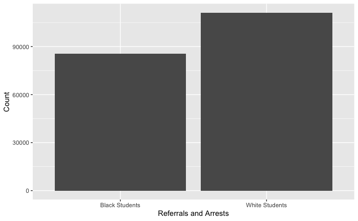

```r
totals <- data.frame(names = c("Black Students","White Students"), sums = c(sum(cleaned$SCH_DISCWODIS_ARR_BL_M, na.rm = TRUE)+sum(cleaned$SCH_DISCWODIS_REF_BL_M, na.rm = TRUE)+sum(cleaned$SCH_DISCWODIS_ARR_BL_F, na.rm = TRUE)+sum(cleaned$SCH_DISCWODIS_REF_BL_F, na.rm = TRUE),sum(cleaned$SCH_DISCWODIS_ARR_WH_M, na.rm = TRUE)+sum(cleaned$SCH_DISCWODIS_ARR_WH_F, na.rm = TRUE)+sum(cleaned$SCH_DISCWODIS_REF_WH_M, na.rm = TRUE)+sum(cleaned$SCH_DISCWODIS_REF_WH_F, na.rm = TRUE)))

totals %>%
  ggplot(aes(x = names, y = sums)) +
  geom_bar(stat = "identity") +
  ylab("Count") +
  xlab("Referrals and Arrests")
```

MY initial intuition has been confirmed. We can see that more white students experience referrals and arrests. However, this does not control for the total number of students that are white or black that attend the public schools. Therefore, we cannot be confident that black students disproportionately receive punishment within public schools. To account for proportionality, I will make a new variable that accounts for proportionality.

```r
cleaned <- cleaned %>%
  mutate(total_bl = SCH_DISCWODIS_REF_BL_M + SCH_DISCWODIS_REF_BL_F + SCH_DISCWODIS_ARR_BL_M + SCH_DISCWODIS_ARR_BL_F, total_wh = SCH_DISCWODIS_REF_WH_M + SCH_DISCWODIS_REF_WH_F + SCH_DISCWODIS_ARR_WH_M + SCH_DISCWODIS_ARR_WH_M)
```

Now that we have the values and variables for proportion, we can visualize it.

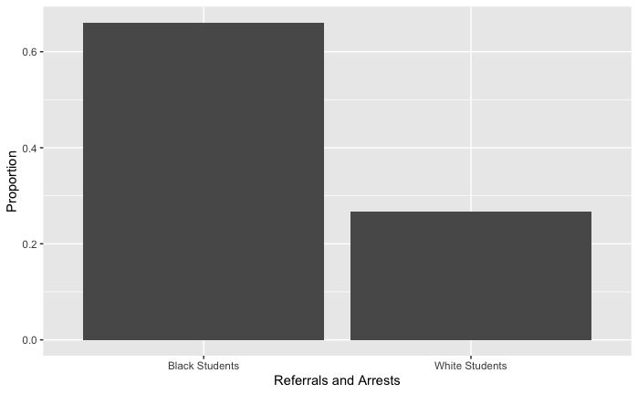

```r
totals2 <- data.frame(names = c("Black Students","White Students"), avg = c((sum(cleaned$total_bl, na.rm = TRUE)/sum(cleaned$SCH_ENR_BL_M+cleaned$SCH_ENR_BL_F, na.rm = TRUE))*100, (sum(cleaned$total_wh, na.rm = TRUE)/sum(cleaned$SCH_ENR_WH_M+cleaned$SCH_ENR_WH_F, na.rm = TRUE))*100))

refAndArrestGraph <- totals2 %>%
  ggplot(aes(x = names, y = avg)) +
  geom_bar(stat = "identity") +
  ylab("Proportion") +
  xlab("Referrals and Arrests")

refAndArrestGraph
```

This makes me curious about other types of punishments namely: Corporal Punishment, Expulsions and Suspensions. I will now analyze these new data sets, visually, in the same method as above.

```r
# Corporal Punishment
cleanedcorPunishment <-
  corPunishment[c("SCHID","SCH_NAME","SCH_DISCWODIS_CORP_BL_M","SCH_DISCWODIS_CORP_BL_F",
                  "SCH_DISCWODIS_CORP_WH_M","SCH_DISCWODIS_CORP_WH_F")]

cleanedcorPunishment$SCH_DISCWODIS_CORP_BL_M[cleanedcorPunishment$SCH_DISCWODIS_CORP_BL_M < 0] <- 0
cleanedcorPunishment$SCH_DISCWODIS_CORP_BL_F[cleanedcorPunishment$SCH_DISCWODIS_CORP_BL_F < 0] <- 0
cleanedcorPunishment$SCH_DISCWODIS_CORP_WH_M[cleanedcorPunishment$SCH_DISCWODIS_CORP_WH_M < 0] <- 0
cleanedcorPunishment$SCH_DISCWODIS_CORP_WH_F[cleanedcorPunishment$SCH_DISCWODIS_CORP_WH_F < 0] <- 0

cleaned3 <- cleanedcorPunishment %>%
  left_join(cleanedenrollment, by = c("SCHID", "SCH_NAME"))

cleaned3 <- cleaned3 %>%
  mutate(total_bl = SCH_DISCWODIS_CORP_BL_M + SCH_DISCWODIS_CORP_BL_F,
         total_wh = SCH_DISCWODIS_CORP_WH_M + SCH_DISCWODIS_CORP_WH_F)

totals3 <- data.frame(names = c("Black Students","White Students"), avg = c((sum(cleaned3$total_bl, na.rm = TRUE)/sum(cleaned3$SCH_ENR_BL_M+cleaned3$SCH_ENR_BL_F, na.rm = TRUE))*100, (sum(cleaned3$total_wh, na.rm = TRUE)/sum(cleaned3$SCH_ENR_WH_M+cleaned$SCH_ENR_WH_F, na.rm = TRUE))*100))

corPunishmentGraph <- totals3 %>%
  ggplot(aes(x = names, y = avg)) +
  geom_bar(stat = "identity") +
  ylab("Proportion") +
  xlab("Corporal Punishment")
```

```r
# Expulsions (with Educational Services)
cleanedexpulsions <-
  expulsions[c("SCHID","SCH_NAME","SCH_DISCWODIS_EXPWE_BL_M","SCH_DISCWODIS_EXPWE_BL_F",
                  "SCH_DISCWODIS_EXPWE_WH_M","SCH_DISCWODIS_EXPWE_WH_F")]

cleanedexpulsions$SCH_DISCWODIS_EXPWE_BL_M[cleanedexpulsions$SCH_DISCWODIS_EXPWE_BL_M < 0] <- 0
cleanedexpulsions$SCH_DISCWODIS_EXPWE_BL_F[cleanedexpulsions$SCH_DISCWODIS_EXPWE_BL_F < 0] <- 0
cleanedexpulsions$SCH_DISCWODIS_EXPWE_WH_M[cleanedexpulsions$SCH_DISCWODIS_EXPWE_WH_M < 0] <- 0
cleanedexpulsions$SCH_DISCWODIS_EXPWE_WH_F[cleanedexpulsions$SCH_DISCWODIS_EXPWE_WH_F < 0] <- 0

cleaned4 <- cleanedexpulsions %>%
  left_join(cleanedenrollment, by = c("SCHID", "SCH_NAME"))

cleaned4 <- cleaned4 %>%
  mutate(total_bl = SCH_DISCWODIS_EXPWE_BL_M + SCH_DISCWODIS_EXPWE_BL_F,
         total_wh = SCH_DISCWODIS_EXPWE_WH_M + SCH_DISCWODIS_EXPWE_WH_F)

totals4 <- data.frame(names = c("Black Students","White Students"), avg = c((sum(cleaned4$total_bl, na.rm = TRUE)/sum(cleaned4$SCH_ENR_BL_M+cleaned4$SCH_ENR_BL_F, na.rm = TRUE))*100, (sum(cleaned4$total_wh, na.rm = TRUE)/sum(cleaned4$SCH_ENR_WH_M+cleaned$SCH_ENR_WH_F, na.rm = TRUE))*100))

expulsionGraph <- totals4 %>%
  ggplot(aes(x = names, y = avg)) +
  geom_bar(stat = "identity") +
  ylab("Proportion") +
  xlab("Expulsions with Educational Services")
```

```r
# ExpulsionsWOE (withOUT Educational Services)
cleanedexpulsionsWOE <-
  expulsions[c("SCHID","SCH_NAME","SCH_DISCWODIS_EXPWOE_BL_M","SCH_DISCWODIS_EXPWOE_BL_F",
                  "SCH_DISCWODIS_EXPWOE_WH_M","SCH_DISCWODIS_EXPWOE_WH_F")]

cleanedexpulsionsWOE$SCH_DISCWODIS_EXPWOE_BL_M[cleanedexpulsionsWOE$SCH_DISCWODIS_EXPWOE_BL_M < 0] <- 0
cleanedexpulsionsWOE$SCH_DISCWODIS_EXPWOE_BL_F[cleanedexpulsionsWOE$SCH_DISCWODIS_EXPWOE_BL_F < 0] <- 0
cleanedexpulsionsWOE$SCH_DISCWODIS_EXPWOE_WH_M[cleanedexpulsionsWOE$SCH_DISCWODIS_EXPWOE_WH_M < 0] <- 0
cleanedexpulsionsWOE$SCH_DISCWODIS_EXPWOE_WH_F[cleanedexpulsionsWOE$SCH_DISCWODIS_EXPWOE_WH_F < 0] <- 0

cleaned5 <- cleaned5 %>%
  mutate(total_bl = SCH_DISCWODIS_EXPWOE_BL_M + SCH_DISCWODIS_EXPWOE_BL_F,
         total_wh = SCH_DISCWODIS_EXPWOE_WH_M + SCH_DISCWODIS_EXPWOE_WH_F)

totals5 <- data.frame(names = c("Black Students","White Students"), avg = c((sum(cleaned5$total_bl, na.rm = TRUE)/sum(cleaned5$SCH_ENR_BL_M+cleaned5$SCH_ENR_BL_F, na.rm = TRUE))*100, (sum(cleaned5$total_wh, na.rm = TRUE)/sum(cleaned5$SCH_ENR_WH_M+cleaned$SCH_ENR_WH_F, na.rm = TRUE))*100))

expulsionGraphWOE <- totals5 %>%
  ggplot(aes(x = names, y = avg)) +
  geom_bar(stat = "identity") +
  ylab("Proportion") +
  xlab("Expulsions without Educational Services")
```

```r
# Suspensions (in-school)
cleanedsuspensions <-
  suspensions[c("SCHID","SCH_NAME","SCH_DISCWODIS_ISS_BL_M","SCH_DISCWODIS_ISS_BL_F",
                  "SCH_DISCWODIS_ISS_WH_M","SCH_DISCWODIS_ISS_WH_F")]

cleanedsuspensions$SCH_DISCWODIS_ISS_BL_M[cleanedsuspensions$SCH_DISCWODIS_ISS_BL_M < 0] <- 0
cleanedsuspensions$SCH_DISCWODIS_ISS_BL_F[cleanedsuspensions$SCH_DISCWODIS_ISS_BL_F < 0] <- 0
cleanedsuspensions$SCH_DISCWODIS_ISS_WH_M[cleanedsuspensions$SCH_DISCWODIS_ISS_WH_M < 0] <- 0
cleanedsuspensions$SCH_DISCWODIS_ISS_WH_F[cleanedsuspensions$SCH_DISCWODIS_ISS_WH_F < 0] <- 0

cleaned6 <- cleanedsuspensions %>%
  left_join(cleanedenrollment, by = c("SCHID", "SCH_NAME"))

cleaned6 <- cleaned6 %>%
  mutate(total_bl = SCH_DISCWODIS_ISS_BL_M + SCH_DISCWODIS_ISS_BL_F,
         total_wh = SCH_DISCWODIS_ISS_WH_M + SCH_DISCWODIS_ISS_WH_F)

totals6 <- data.frame(names = c("Black Students","White Students"), avg = c((sum(cleaned6$total_bl, na.rm = TRUE)/sum(cleaned6$SCH_ENR_BL_M+cleaned6$SCH_ENR_BL_F, na.rm = TRUE))*100, (sum(cleaned6$total_wh, na.rm = TRUE)/sum(cleaned6$SCH_ENR_WH_M+cleaned$SCH_ENR_WH_F, na.rm = TRUE))*100))

suspensiongraph <- totals6 %>%
  ggplot(aes(x = names, y = avg)) +
  geom_bar(stat = "identity") +
  ylab("Proportion") +
  xlab("In-School Suspensions")
```

```r
# Suspensions (out-of-school)
cleanedsuspensionsOOS <-
  suspensions[c("SCHID","SCH_NAME","SCH_DISCWODIS_SINGOOS_BL_M","SCH_DISCWODIS_SINGOOS_BL_F",
                  "SCH_DISCWODIS_SINGOOS_WH_M","SCH_DISCWODIS_SINGOOS_WH_F","SCH_DISCWODIS_MULTOOS_BL_M","SCH_DISCWODIS_MULTOOS_BL_F",
                  "SCH_DISCWODIS_MULTOOS_WH_M","SCH_DISCWODIS_MULTOOS_WH_F")]

cleanedsuspensionsOOS$SCH_DISCWODIS_SINGOOS_BL_M[cleanedsuspensionsOOS$SCH_DISCWODIS_SINGOOS_BL_M < 0] <- 0
cleanedsuspensionsOOS$SCH_DISCWODIS_SINGOOS_BL_F[cleanedsuspensionsOOS$SCH_DISCWODIS_SINGOOS_BL_F < 0] <- 0
cleanedsuspensionsOOS$SCH_DISCWODIS_SINGOOS_WH_M[cleanedsuspensionsOOS$SCH_DISCWODIS_SINGOOS_WH_M < 0] <- 0
cleanedsuspensionsOOS$SCH_DISCWODIS_SINGOOS_WH_F[cleanedsuspensionsOOS$SCH_DISCWODIS_SINGOOS_WH_F < 0] <- 0
cleanedsuspensionsOOS$SCH_DISCWODIS_MULTOOS_BL_M[cleanedsuspensionsOOS$SCH_DISCWODIS_MULTOOS_BL_M < 0] <- 0
cleanedsuspensionsOOS$SCH_DISCWODIS_MULTOOS_BL_F[cleanedsuspensionsOOS$SCH_DISCWODIS_MULTOOS_BL_F < 0] <- 0
cleanedsuspensionsOOS$SCH_DISCWODIS_MULTOOS_WH_M[cleanedsuspensionsOOS$SCH_DISCWODIS_MULTOOS_WH_M < 0] <- 0
cleanedsuspensionsOOS$SCH_DISCWODIS_MULTOOS_WH_F[cleanedsuspensionsOOS$SCH_DISCWODIS_MULTOOS_WH_F < 0] <- 0

cleaned8 <- cleanedsuspensionsOOS %>%
  left_join(cleanedenrollment, by = c("SCHID", "SCH_NAME"))

cleaned8 <- cleaned8 %>%
  mutate(total_bl = SCH_DISCWODIS_SINGOOS_BL_M + SCH_DISCWODIS_SINGOOS_BL_F + SCH_DISCWODIS_MULTOOS_BL_M + SCH_DISCWODIS_MULTOOS_BL_F, total_wh = SCH_DISCWODIS_SINGOOS_WH_M + SCH_DISCWODIS_SINGOOS_WH_F + SCH_DISCWODIS_MULTOOS_WH_M + SCH_DISCWODIS_MULTOOS_WH_F)

totals8 <- data.frame(names = c("Black Students","White Students"), avg = c((sum(cleaned8$total_bl, na.rm = TRUE)/sum(cleaned8$SCH_ENR_BL_M+cleaned8$SCH_ENR_BL_F, na.rm = TRUE))*100, (sum(cleaned8$total_wh, na.rm = TRUE)/sum(cleaned8$SCH_ENR_WH_M+cleaned8$SCH_ENR_WH_F, na.rm = TRUE))*100))

suspensiongraphOOS <- totals8 %>%
  ggplot(aes(x = names, y = avg)) +
  geom_bar(stat = "identity") +
  ylab("Proportion") +
  xlab("Out-of-School Suspensions")
```

Now that we have the graphs, let’s compare them all side-by-side.

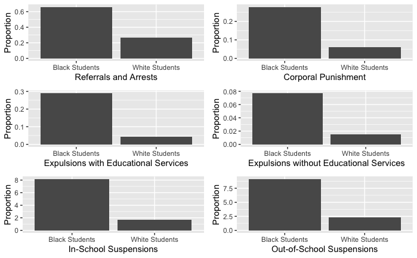

```r
grid.arrange(refAndArrestGraph, corPunishmentGraph, expulsionGraph, expulsionGraphWOE, suspensiongraph, suspensiongraphOOS)
```

Let’s re-define punishment as a blanket term for referrals, arrests, corporal punishment, expulsions (of both types), and suspensions (of both types). We can now visualize the total proportion of punishment received by both black and white students.

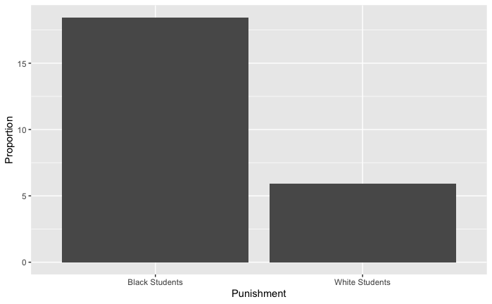

```r
# Columns to merge "by"
mergeCols <- c("SCHID", "SCH_NAME")
# Recursively left_join until we get one dataframe with all the necessary variables
allCleaned <- left_join(cleanedenrollment, left_join(cleanedrefAndArrest, left_join(cleanedcorPunishment, left_join(cleanedexpulsions, left_join(cleanedexpulsionsWOE, left_join(cleanedsuspensions, cleanedsuspensionsOOS,by = mergeCols), by = mergeCols), by = mergeCols), by = mergeCols), by = mergeCols), by = mergeCols)
# Calculate sum across rows for all black students
allCleaned_bl <- allCleaned[, grep(pattern = "BL_.$", x = colnames(allCleaned))]
allCleaned_bl <- allCleaned_bl[3:18]
allCleaned <- allCleaned %>%
  mutate(total_bl = rowSums(allCleaned_bl[1:16]))
# Calculate sum across rows for all white students
allCleaned_wh <- allCleaned[, grep(pattern = "WH_.$", x = colnames(allCleaned))]
allCleaned_wh <- allCleaned_wh[3:18]
allCleaned <- allCleaned %>%
  mutate(total_wh = rowSums(allCleaned_wh[1:16]))

totals9 <- data.frame(names = c("Black Students","White Students"), avg = c((sum(allCleaned$total_bl, na.rm = TRUE)/sum(allCleaned$SCH_ENR_BL_M + allCleaned$SCH_ENR_BL_F, na.rm = TRUE))*100, (sum(allCleaned$total_wh, na.rm = TRUE)/sum(allCleaned$SCH_ENR_WH_M + allCleaned$SCH_ENR_WH_F, na.rm = TRUE))*100))

totalGraph <- totals9 %>%
  ggplot(aes(x = names, y = avg)) +
  geom_bar(stat = "identity") +
  ylab("Proportion") +
  xlab("Punishment")

totalGraph
```

This graph illustrates the disproportionate punishment of black students verses white students in the public school system. About 18 percent of black students faced punishment compared to 6 percent of their white counterparts.

Now that we’ve seen the pattern from America as a whole, we want to narrow his down to states.

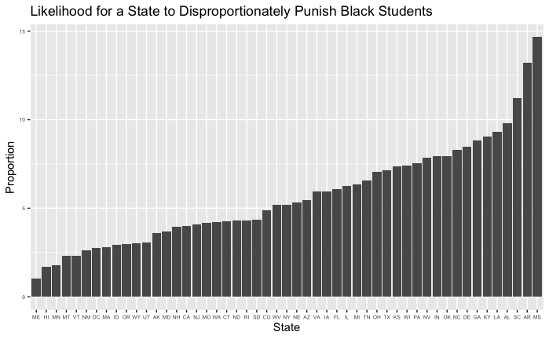

```r
states <- enrollment[1:6]

mergeCols <- c("SCHID", "SCH_NAME")
allCleaned_States <- states %>%
  left_join(allCleaned, by = mergeCols)

allCleaned_States <- allCleaned_States %>%
  mutate(proportion_bl = total_bl/(SCH_ENR_BL_M+SCH_ENR_BL_F), proportion_wh = total_wh/(SCH_ENR_WH_M+SCH_ENR_WH_F), proportion_bl_likely = proportion_bl - proportion_wh)

morelikely_State <- allCleaned_States %>%
  group_by(LEA_STATE) %>%
  summarise(mean_morelikely = mean(proportion_bl_likely, na.rm = TRUE)*100) %>%
  filter(LEA_STATE != "PR") %>%
  arrange(-desc(mean_morelikely))

morelikely_State %>%
  mutate(LEA_STATE = factor(LEA_STATE, levels = LEA_STATE)) %>%
  ggplot(aes(x = LEA_STATE, y = mean_morelikely)) +
  geom_bar(stat = "identity") +
  ggtitle("Likelihood for a State to Disproportionately Punish Black Students") +
  xlab("State") +
  ylab("Proportion") +
  theme(axis.text=element_text(size=5))
```

I created a new variable called *mean_morelikely* which gives us the likelihood of a state to punish black student over white students. For example, Mississippi (all the way on the right) is more than 14% more likely to punish a black student over a white student.

Since we’ve narrowed out findings to the state level, we can map whatever characteristics to that state to show a possible correlation. In the next example, I joined a state’s political party affiliation from 2017 (Democrat or Republican) from a Gallup Poll (https://news.gallup.com/poll/226643/2017-party-affiliation-state.aspx). This characteristic is shown through the color of the bars.

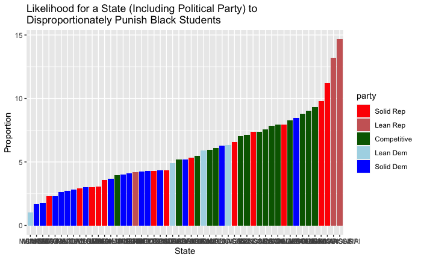

```r
party <- party %>%
  mutate(state = toupper(state))

morelikely_State <- allCleaned_States %>%
  select(LEA_STATE, LEA_STATE_NAME, proportion_bl_likely) %>%
  group_by(LEA_STATE_NAME) %>%
  summarise(mean_morelikely = mean(proportion_bl_likely, na.rm = TRUE)*100) %>%
  left_join(party, by = c("LEA_STATE_NAME" = "state")) %>%
  filter(LEA_STATE_NAME != "PUERTO RICO") %>%
  arrange(-desc(mean_morelikely))

morelikely_State$party<- factor(morelikely_State$party, c("Solid Dem", "Lean Dem", "Competitive", "Lean Rep", "Solid Rep"))
morelikely_State$party <- factor(morelikely_State$party, levels = rev(levels(morelikely_State$party)))

morelikely_State %>%
  mutate(LEA_STATE_NAME = factor(LEA_STATE_NAME, levels = LEA_STATE_NAME))  %>%
  ggplot(aes(x = LEA_STATE_NAME, y = mean_morelikely)) +
  geom_bar(aes(fill = party), stat = "identity") +
  labs(title = "Likelihood for a State (Including Political Party) to \nDisproportionately Punish Black Students", x = "State" , y = "Proportion") +
  scale_fill_manual(values = c("red","#CC6666","dark green","light blue","blue"))
```

It looks like states that are “competitive” are the majority when it comes to the right half of the graph. The majority of the states on the left half of the graph tend to be more “democratic”.

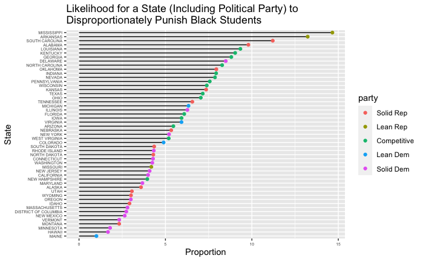

```r
morelikely_State %>%
  mutate(LEA_STATE_NAME = factor(LEA_STATE_NAME, levels = LEA_STATE_NAME))  %>%
  ggplot(aes(x = LEA_STATE_NAME, y = mean_morelikely)) +
  geom_segment(aes(xend = LEA_STATE_NAME, yend = 0)) +
  geom_point(aes(color = party)) +
  coord_flip() +
  labs(title = "Likelihood for a State (Including Political Party) to \nDisproportionately Punish Black Students", x = "State" , y = "Proportion") +
  theme(axis.text=element_text(size=5))
```

This graph would be better representation of the graph above for the viewer. The full state names are not cluttered and the segments are easier to follow visually. The point at the end of the segment not only precisely show proportion but also the party affiliation of the state.

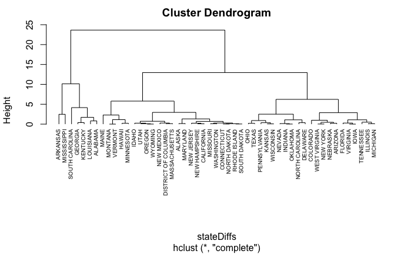

```r
stateDiffs <- dist(morelikely_State)
stateDiffs <- dist_setNames(stateDiffs, morelikely_State$LEA_STATE_NAME)
cluster <- hclust(stateDiffs)
plot(cluster, hang = -1, cex = 0.6)
```

In this example of clustering, we can see that the unsupervised learning was very intuitive. Arkansas and Mississippi are the closest to each other and it makes sense since they are the two states that are the most likely to disproportionately punish black students.

### Conclusion

In terms of my guiding question, it seems as if black students face disproportionate punishment compared to their white counterparts within the public school system in the United States. I was surprised to see that every category of punishment was disproportionate. Furthermore, it looks like every single state is more likely to punish black students than white students to some extend.

I would be interested to see how much further we can narrow down the geographic span of the analysis (school districts and counties). Also, I would interested in seeing the significance of this analysis through quantitative tests.